# preprocessamento

### ⚠️ Roteiro para executar códigos do notebook no Google Colab(oratory) com GPU_

**PASSO 1:** Acessar https://colab.research.google.com/ $\to$ `Upload` $\to$ `escolher arquivo .ipynb`

**PASSO 2:** Acessar MENU `Ambiente de execução` $\to$ `Alterar tipo do ambiente` $\to$ `GPU` $\to$ `Salvar`

**PASSO 3:** `Barra lateral esquerda` $\to$ `Icone de arquivo` $\to$ `Icone de upload` $\to$ `escolher arquivo auxiliar` (ex. `aux.py`)

**PASSOS 4, 5, 6 e 7:** ver células a seguir...

```python
#### PASSO 4: VER DETALHES DA GPU
#### Descomente a linha abaixo e execute

#!nvidia-smi
```

```python
#### PASSO 5: VER VERSÃO CUDA INSTALADA
#### Descomente a linha abaixo e execute

#!nvcc --version
```

```python
#### PASSO 6: INSTALAR versão MXNET com versão CUDA correspondente
#### Descomente uma das linhas abaixo e execute

#!pip install -U mxnet-cu110==1.8.0
#!pip install -U mxnet-cu101==1.7.0
```

```python
#### PASSO 7: VERIFICAR se MXNET "enxerga" a GPU
#### Se estiver enxergando, será impresso algo como gpu(0),
#### caso contrário, será impresso algo como cpu(0)
#### Descomente o código abaixo e execute

#from mxnet import npx
#def try_all_gpus():
#    devices = [npx.gpu(i) for i in range(npx.num_gpus())]
#    return devices if devices else [npx.cpu()]
#try_all_gpus()
```

# Dados: aspectos de pré-processamento e outras reflexões

## Estudo de caso: previsão dos preços de casas

Competição no Kaggle: https://www.kaggle.com/c/house-prices-advanced-regression-techniques/data

```python
%matplotlib inline
#from d2l import mxnet as d2l
import aux
from mxnet import autograd, gluon, init, nd
from mxnet.gluon import data as gdata, loss as gloss, nn, utils
import numpy as np
import pandas as pd
```

## Leitura dos datasets

```python
# Descomente a linha abaixo e forneça a
# URL da base desejada (entre apóstrofos) para download

#utils.download('url_do_dataset')

train_data = pd.read_csv('./house/train.csv')
test_data = pd.read_csv('./house/test.csv')

# dimensão dos datasets
print(train_data.shape)
print(test_data.shape)

# fatia ilustrativa: primeiros 4 exemplos, primeiras 4 e últimas 2 características,
# e coluna da variável dependente (preço da casa)
train_data.iloc[0:4, [0, 1, 2, 3, -3, -2, -1]]
```

```
(1460, 81)
(1459, 80)
```

|  | Id | MSSubClass | MSZoning | LotFrontage | SaleType | SaleCondition | SalePrice |
| --- | --- | --- | --- | --- | --- | --- | --- |
| 0 | 1 | 60 | RL | 65.0 | WD | Normal | 208500 |
| 1 | 2 | 20 | RL | 80.0 | WD | Normal | 181500 |
| 2 | 3 | 60 | RL | 68.0 | WD | Normal | 223500 |
| 3 | 4 | 70 | RL | 60.0 | WD | Abnorml | 140000 |

## Pré-processamento dos dados

1. Reescala de características
2. Dados faltantes
3. Dados categóricos

```python
# Unificar os datasets para unificar as tarefas de pré-processamento,
# evitando-se re-trabalho com bases separadas
all_features = pd.concat((train_data.iloc[:, 1:-1], test_data.iloc[:, 1:]))
```

### 1. Reescala de características

#### Por que?

1. Igualar importância das características: para a máquina, tudo é número. Logo...  
   $x_1$ (altura em m): 1,5 até 2,0  
   $x_2$ (idade em anos): 18 até 80  
   $\implies$ importância de $x_2 >> x_1$ em $x_1*w_1 + x_2*w_2 + b$
2. Velocidade da convergência da Descida do Gradiente

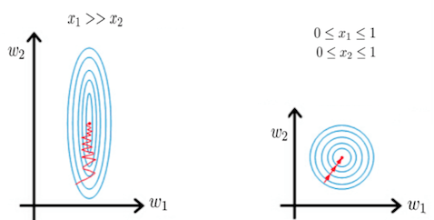

#### Tipos

1. Max-Min (*normalization*)

$$x_{norm} \leftarrow \frac{x - x_{min}}{x_{max}-x_{min}}$$

1. Pelo desvio padrão (*standardization*) $\implies$ características passam a ter $\mu=0, \sigma=1$

$$x_{std} \leftarrow \frac{x - \mu}{\sigma}$$

```python
numeric_features = all_features.dtypes[all_features.dtypes != 'object'].index
all_features[numeric_features] = all_features[numeric_features].apply(
    lambda x: (x - x.mean()) / (x.std())) # tipo 2. standardization
```

### 2. Dados faltantes (ou NaN)

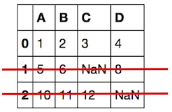

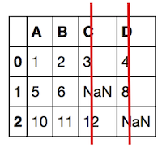

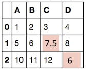

#### Após *standardization* seria mais intuitivo...

... substituir por ZERO os NaN gerados

```python
# Substituindo Na/NaN por zero
all_features = all_features.fillna(0)
```

### 3. Lidando com dados categóricos

#### Problemas

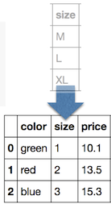

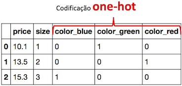

```python
#get_dummies = one-hot
all_features = pd.get_dummies(all_features, dummy_na=True)
#número de características aumenta porque cada uma anterior se torna 2 ou mais
all_features.shape
```

```
(2919, 354)
```

## Datasets pré-processados

```python
# Atributo values: formato NumPy a partir do formato pandas
# ...gera os Tensors
n_train = train_data.shape[0]
train_features = nd.array(all_features[:n_train].values)
test_features = nd.array(all_features[n_train:].values)
train_labels = nd.array(train_data.SalePrice.values).reshape((-1, 1))
```

## Treinamento com Regressão Linear e Regularização $L_2$

```python
loss = gloss.L2Loss()

def get_net():
    net = nn.Sequential()
    net.add(nn.Dense(1))
    net.initialize()
    return net
```

### Função de erro do Kaggle para as competições prioriza o erro relativo

Ao invés da diferença absoluta entre o valor previsto e o real, prioriza-se a diferença relativa: $y - \hat{y} \implies \frac{y - \hat{y}}{y}$

#### Log Root Mean Square Error

$$L = \sqrt{\frac{1}{n}\sum_{i=1}^n\left(\log y_i -\log \hat{y}_i\right)^2}$$

```python
# Log Root Mean Square Error
def log_rmse(net, features, labels):
    clipped_preds = nd.clip(net(features), 1, float('inf'))
    rmse = nd.sqrt(2 * loss(clipped_preds.log(), labels.log()).mean())
    return rmse.asscalar()
```

## Função de treinamento

Algoritmo de aprendizado `adam` vs. tradicional `sgd`.

`adam` **adapta a taxa de aprendizagem** aos parâmetros, fazendo pequenas atualizações para as características mais frequentes e grandes atualizações para as mais raras. Assim, a rede é capaz de capturar informações pertencentes a características que não são tão freqüentes, colocando-as em evidência e atribuindo-lhes o peso certo. **No geral, é a melhor escolha.**

```python
def train(net, train_features, train_labels, test_features, test_labels,
          num_epochs, learning_rate, weight_decay, batch_size):
    train_ls, test_ls = [], []
    train_iter = gdata.DataLoader(gdata.ArrayDataset(
        train_features, train_labels), batch_size, shuffle=True)
    trainer = gluon.Trainer(net.collect_params(), 'adam', {
        'learning_rate': learning_rate, 'wd': weight_decay})
    for epoch in range(num_epochs):
        for X, y in train_iter:
            with autograd.record():
                l = loss(net(X), y)
            l.backward()
            trainer.step(batch_size)
        train_ls.append(log_rmse(net, train_features, train_labels))
        if test_labels is not None:
            test_ls.append(log_rmse(net, test_features, test_labels))
    return train_ls, test_ls
```

## Validação cruzada k-Fold

Lembrete: k pedaços diferentes do dataset de treinamento são usados para validação

```python
# Extração do dataset de validação k desejado
def get_k_fold_data(k, i, X, y):
    assert k > 1
    fold_size = X.shape[0] // k
    X_train, y_train = None, None
    for j in range(k):
        idx = slice(j * fold_size, (j + 1) * fold_size)
        X_part, y_part = X[idx, :], y[idx]
        if j == i:
            X_valid, y_valid = X_part, y_part
        elif X_train is None:
            X_train, y_train = X_part, y_part
        else:
            X_train = nd.concat(X_train, X_part, dim=0)
            y_train = nd.concat(y_train, y_part, dim=0)
    return X_train, y_train, X_valid, y_valid
```

```python
# Função de validação cruzada realiza o treinamento k vezes
def k_fold(k, X_train, y_train, num_epochs,
           learning_rate, weight_decay, batch_size):
    train_l_sum, valid_l_sum = 0, 0
    # Repete o laço de treinamento k vezes, cada vez executa num-epochs
    for i in range(k):
        data = get_k_fold_data(k, i, X_train, y_train)
        net = get_net()
        train_ls, valid_ls = train(net, data[0],data[1],data[2],data[3], num_epochs, learning_rate,
                                   weight_decay, batch_size)
        train_l_sum += train_ls[-1]
        valid_l_sum += valid_ls[-1]
        # Plotagem representa todas as rmse ao longo das épocas para o fold 0 exclusivamente
        if i == 0:
            aux.plot(list(range(1, num_epochs + 1)), [train_ls, valid_ls],
                     xlabel='época (fold 0)', ylabel='rmse', xlim=[1, num_epochs],
                     legend=['treino', 'valid'], yscale='log')
        # Impressão representa a rmse da última época para cada fold
        print('fold %d, treino rmse: %f, valid rmse: %f' % (
            i, train_ls[-1], valid_ls[-1]))
    return train_l_sum / k, valid_l_sum / k
```

## Hiperparâmetros e execução do treinamento

```python
# modificar parâmetros e observar efeitos
k, num_epochs, lr, weight_decay, batch_size = 5, 100, 5, 0.001, 64
train_l, valid_l = k_fold(k, train_features, train_labels, num_epochs, lr,
                          weight_decay, batch_size)
print('[Validação %d-fold] Média rmse de treino: %f, Média rmse de validação: %f'
      % (k, train_l, valid_l))
```

```
fold 0, treino rmse: 0.169918, valid rmse: 0.157314
fold 1, treino rmse: 0.162231, valid rmse: 0.189447
fold 2, treino rmse: 0.163774, valid rmse: 0.168127
fold 3, treino rmse: 0.167855, valid rmse: 0.154568
fold 4, treino rmse: 0.162849, valid rmse: 0.182870
[Validação 5-fold] Média rmse de treino: 0.165326, Média rmse de validação: 0.170465
```

[figure not shown]

## Modelo final e submissão ao Kaggle

1. A melhor combinação de hiperparâmetros da etapa anterior é usada
2. Treinamento agora é realizado com o dataset de treino completo (não há reserva para k validações)
3. O dataset de Teste agora é usado para gerar as previsões finais
4. Planilha (csv) com essas previsões é gerada para ser submetida ao Kaggle

```python
# Últimos hiperparâmetros definidos são usados
def train_and_pred(train_features, test_feature, train_labels, test_data,
                   num_epochs, lr, weight_decay, batch_size):
    net = get_net()

    # Treinamento é feito com o dataset completo
    train_ls, _ = train(net, train_features, train_labels, None, None,
                        num_epochs, lr, weight_decay, batch_size)
    aux.plot(np.arange(1, num_epochs + 1), [train_ls], xlabel='época',
             ylabel='log rmse', xlim=[1, num_epochs], yscale='log')
    print(f'treino log rmse {float(train_ls[-1]):f}')

    # As previsões para o dataset de Teste são geradas a partir do modelo treinado
    preds = net(test_features).asnumpy()
    test_data['SalePrice'] = pd.Series(preds.reshape(1, -1)[0])

    # Criação do CSV de resposta à competição
    submission = pd.concat([test_data['Id'], test_data['SalePrice']], axis=1)
    submission.to_csv('./house/submission.csv', index=False)

# Execução da função de treinamento e teste
train_and_pred(train_features, test_features, train_labels, test_data,
               num_epochs, lr, weight_decay, batch_size)
```

```
treino log rmse 0.162770
```

[figure not shown]

# Referências para estudo

## Seção 4.10 de [Dive into Deep Learning](https://d2l.ai/index.html)

# Mais reflexões sobre os dados

### Problema 1 - a distribuição da amostragem "mente": $P_{emp}(x, y) \neq P(x, y)$

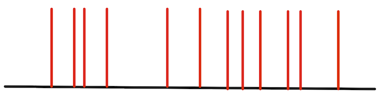

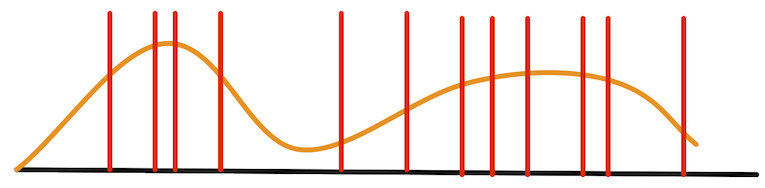

#### Melhorias possíveis

- Inserir ruídos nos dados de entrada
- Dropout
- Regularização

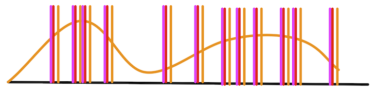

### Problema 2 - a distribuição das características "mente": $P(\mathbf{x}) \neq Q(\mathbf{x})$

(*covariate shift*)

A distribuição das entradas muda com o tempo enquanto que a função de rotulação permanece a mesma. Por exemplo, na hora de aplicar o modelo treinado, os novos dados (teste) seguem uma distribuição diferente, $Q(\mathbf{x})$, e continuamos usando o mesmo modelo já treinado anteriormente: $P(y|\mathbf{x})$. Ou seja, $Q(y,\mathbf{x}) = P(y|\mathbf{x})*Q(\mathbf{x})$. Isso acontece muito quando acreditamos que $\mathbf{x}$ causa $y$.

**Treinamento**

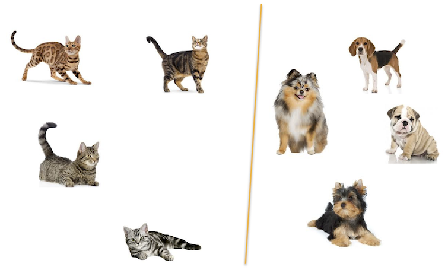

**Teste**

[figure not shown]

#### Exemplos

**Busca na Web**  
Treinamento: conteúdo de sites de Sergipe  
Teste: recomendar sites para Alagoas

**Reconhecimento de fala**  
Treinamento: falas gravadas de sergipanos | falas gravadas de crianças  
Teste: reconhecer falas de gaúchos | reconhecer falas de adultos

**Reconhecimento de texto**  
Treinamento: textos de artigos científicos  
Teste: compreender textos de redes sociais

**Diagnóstico médico (ex: COVID)**  
Treinamento: amostras de pessoas doentes no hospital (maioria idosos) e de pessoas voluntárias (maioria jovens)  
Teste: diagnosticar pessoas com sintomas no hospital (maioria idosos)

### Problema 3 - a distribuição dos rótulos "mente": $P(y) \neq Q(y)$

(*label shift*)

Problema oposto ao anterior: a distribuição dos rótulos muda com o tempo enquanto que a função de verossimilhança permanece a mesma. Ou seja, $Q(\mathbf{x},y) = P(\mathbf{x}|y)*Q(y)$. Isso é um problema em domínios onde claramente $y$ causa $\mathbf{x}$. Por exemplo, doença ($y$) causa os sintomas ($\mathbf{x}$) e não o contrário.

**Treinamento**

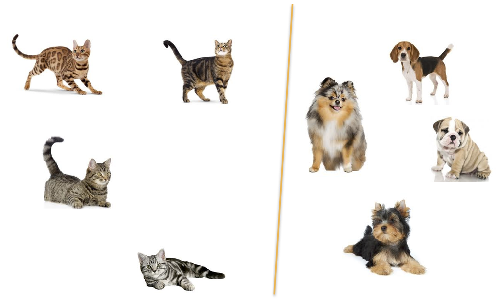

**Teste**

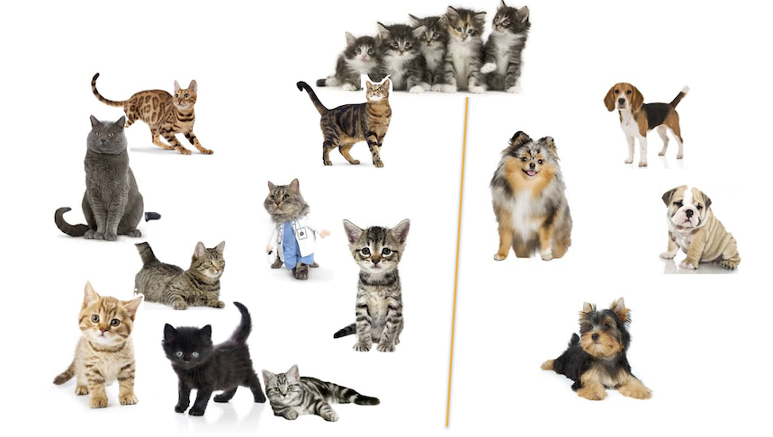

#### Exemplo

**Diagnóstico médico**  
Treinamento: dados de pacientes sãos e doentes ($\approx 50\%$)  
Teste: dados de pessoas durante temporada de gripe ($Q(y="gripado") >> P(y="gripado")$ enquanto que os sintomas da gripe permanecem os mesmos: $P(sintomas|"gripado")$

### Estas reflexões são levantadas na seção 4.9 de [Dive into Deep Learning](https://d2l.ai/index.html)